# EDS 232 - Lab 2a: Clustering

Steven Cognac

1/24/2022

# 1 Clustering

Clustering associates similar data points with each other, adding a grouping label. It is a form of unsupervised learning since we don’t fit the model based on feeding it a labeled response (i.e. y).

## 1.1 K-Means Clustering

Source:[K Means Clustering in R | DataScience+](https://datascienceplus.com/k-means-clustering-in-r/)  
In k-means clustering, the number of clusters needs to be specified. The algorithm randomly assigns each observation to a cluster, and finds the centroid of each cluster. Then, the algorithm iterates through two steps:

1. Reassign data points to the cluster whose centroid is closest.
2. Calculate new centroid of each cluster.

These two steps are repeated until the within cluster variation cannot be reduced any further. The within cluster variation is calculated as the sum of the euclidean distance between the data points and their respective cluster centroids.

### 1.1.1 Load and plot the `iris` dataset

```r
# load the dataset
data("iris")

# look at documentation in RStudio
if (interactive())
  help(iris)

# show data table
datatable(iris)
```

|  | Sepal.Length | Sepal.Width | Petal.Length | Petal.Width | Species |
| --- | --- | --- | --- | --- | --- |
| 1 | 5.1 | 3.5 | 1.4 | 0.2 | setosa |
| 2 | 4.9 | 3 | 1.4 | 0.2 | setosa |
| 3 | 4.7 | 3.2 | 1.3 | 0.2 | setosa |
| 4 | 4.6 | 3.1 | 1.5 | 0.2 | setosa |
| 5 | 5 | 3.6 | 1.4 | 0.2 | setosa |
| 6 | 5.4 | 3.9 | 1.7 | 0.4 | setosa |
| 7 | 4.6 | 3.4 | 1.4 | 0.3 | setosa |
| 8 | 5 | 3.4 | 1.5 | 0.2 | setosa |
| 9 | 4.4 | 2.9 | 1.4 | 0.2 | setosa |
| 10 | 4.9 | 3.1 | 1.5 | 0.1 | setosa |

[output cut: 140 more lines]

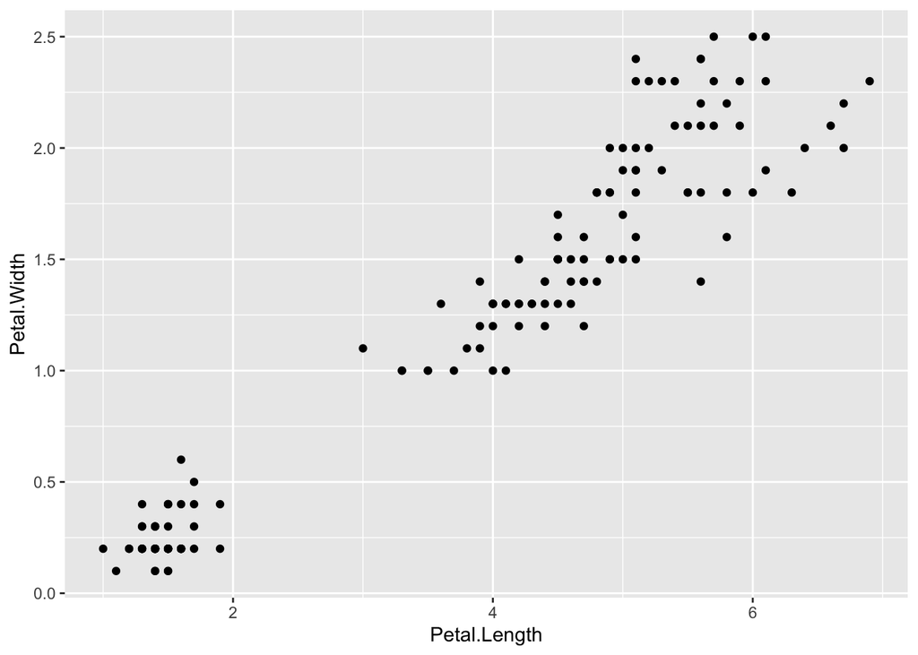

```r
# plot petal length vs width, species naive
ggplot(
  iris, aes(Petal.Length, Petal.Width)) +
  geom_point()
```

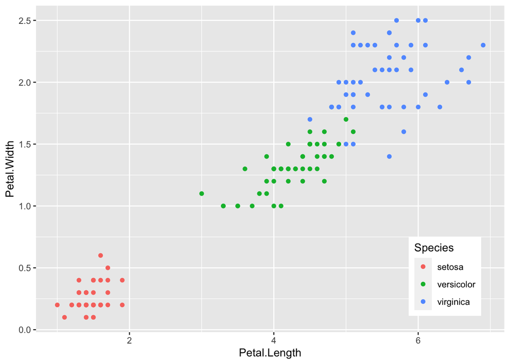

```r
# plot petal length vs width, color by species
legend_pos <- theme(
    legend.position = c(0.95, 0.05),
    legend.justification = c("right", "bottom"),
    legend.box.just = "right")
ggplot(
  iris, aes(Petal.Length, Petal.Width, color = Species)) +
  geom_point() +
  legend_pos
```

### 1.1.2 Cluster `iris` using `kmeans()`

```r
# cluster using kmeans
k <- 3  # number of clusters
iris_k <- kmeans(
  iris %>%
    select(Petal.Length, Petal.Width),
  centers = k)

# show cluster result
iris_k
```

```
## K-means clustering with 3 clusters of sizes 50, 52, 48
##
## Cluster means:
##   Petal.Length Petal.Width
## 1     1.462000    0.246000
## 2     4.269231    1.342308
## 3     5.595833    2.037500
##
## Clustering vector:
##   [1] 1 1 1 1 1 1 1 1 1 1 1 1 1 1 1 1 1 1 1 1 1 1 1 1 1 1 1 1 1 1 1 1 1 1 1 1 1
##  [38] 1 1 1 1 1 1 1 1 1 1 1 1 1 2 2 2 2 2 2 2 2 2 2 2 2 2 2 2 2 2 2 2 2 2 2 2 2
##  [75] 2 2 2 3 2 2 2 2 2 3 2 2 2 2 2 2 2 2 2 2 2 2 2 2 2 2 3 3 3 3 3 3 2 3 3 3 3
## [112] 3 3 3 3 3 3 3 3 2 3 3 3 3 3 3 2 3 3 3 3 3 3 3 3 3 3 3 2 3 3 3 3 3 3 3 3 3
## [149] 3 3
##
## Within cluster sum of squares by cluster:
## [1]  2.02200 13.05769 16.29167
##  (between_SS / total_SS =  94.3 %)
##
## Available components:
##
## [1] "cluster"      "centers"      "totss"        "withinss"     "tot.withinss"
## [6] "betweenss"    "size"         "iter"         "ifault"
```

```r
# compare clusters with species (which were not used to cluster)
table(iris_k$cluster, iris$Species)
```

```
##
##     setosa versicolor virginica
##   1     50          0         0
##   2      0         48         4
##   3      0          2        46
```

**Question: How many observations could be considered “mis-classified” if expecting petal length and width to differentiate between species?** - Based on the original `iris` dataset, there are a total of 150 observations with 50 datapoints for each species. With the k-means classification when $k=3$, there is 6 datapoints that could be considered “mis-classified”.

```r
# species classification totals
iris_tot <- iris %>%
  count(Species)
iris_tot
```

```
##      Species  n
## 1     setosa 50
## 2 versicolor 50
## 3  virginica 50
```

```r
# k-means classification totals
iris_k_tot <- iris_k[["size"]]
iris_k_tot
```

```
## [1] 50 52 48
```

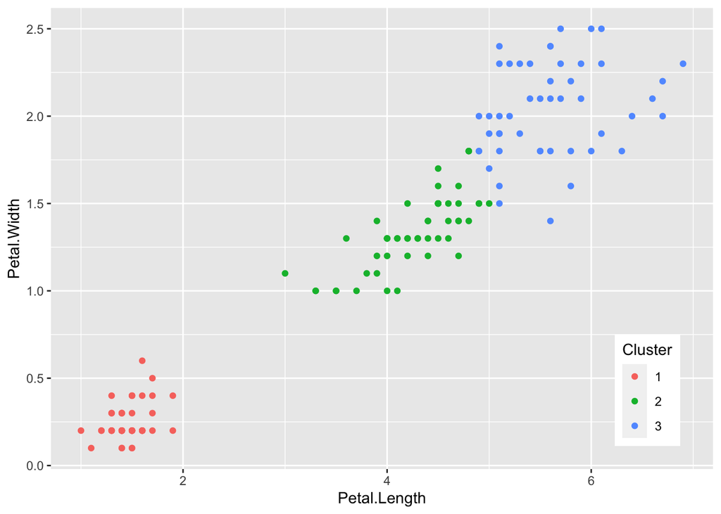

```r
# extract cluster assignment per observation
Cluster = factor(iris_k$cluster)

ggplot(iris, aes(Petal.Length, Petal.Width, color = Cluster)) +
  geom_point() +
  legend_pos
```

### 1.1.3 Plot Voronoi diagram of clustered `iris`

This form of clustering assigns points to the cluster based on nearest centroid. You can see the breaks more clearly with a [Voronoi diagram](https://en.wikipedia.org/wiki/Voronoi_diagram).

```r
librarian::shelf(ggvoronoi, scales)
```

[output not shown]

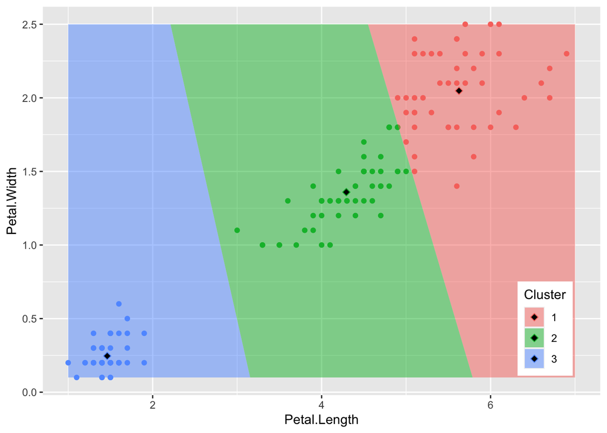

```r
# define bounding box for geom_voronoi()
box <- tribble(
  ~Petal.Length, ~Petal.Width, ~group,
  1, 0.1, 1,
  1, 2.5, 1,
  7, 2.5, 1,
  7, 0.1, 1,
  1, 0.1, 1) %>%
  data.frame()

# cluster using kmeans
k <- 3  # number of clusters
iris_k <- kmeans(
  iris %>%
    select(Petal.Length, Petal.Width),
  centers = k)

# extract cluster assignment per observation
Cluster = factor(iris_k$cluster)

# extract cluster centers
ctrs <- as.data.frame(iris_k$centers) %>%
  mutate(
    Cluster = factor(1:k))

# plot points with voronoi diagram showing nearest centroid
ggplot(iris, aes(Petal.Length, Petal.Width, color = Cluster)) +
  geom_point() +
  legend_pos +
  geom_voronoi(
    data = ctrs, aes(fill=Cluster), color = NA, alpha=0.5, outline = box) +
  geom_point(
    data = ctrs, pch=23, cex=2, fill="black")
```

## 1.2 Hierarchical Clustering

Cluster sites according to species composition. Use the `dune` dataset from the vegan R package.

### 1.2.1 Load `dune` dataset

```r
librarian::shelf(
  cluster, vegan)
```

[output not shown]

```r
# load dune dataset from package vegan
data("dune")

# show documentation on dataset if interactive
if (interactive())
  help(dune)
```

**Question: What are the rows and columns composed of in the dune data frame?**  
- Columns are observations of 30 vegetative dune meadow species.  
- Rows are the 20 sites where the species were observed.

### 1.2.2 Calculate Ecological Distances on sites

Preparation of concepts with easier dataset `sites`

```r
sites <- tribble(
  ~site, ~sp1, ~sp2, ~sp3,
    "A",    1,    1,    0,
    "B",    5,    5,    0,
    "C",    0,    0,    1) %>%
  column_to_rownames("site")
sites
```

```
##   sp1 sp2 sp3
## A   1   1   0
## B   5   5   0
## C   0   0   1
```

```r
# Computation of Dissimilarity Indices for Community Ecologists
sites_manhattan <- vegdist(sites, method="manhattan")
sites_manhattan
```

```
##    A  B
## B  8
## C  3 11
```

```r
sites_euclidean <- vegdist(sites, method="euclidean")
sites_euclidean
```

```
##          A        B
## B 5.656854
## C 1.732051 7.141428
```

```r
sites_bray <- vegdist(sites, method="bray")
sites_bray
```

```
##           A         B
## B 0.6666667
## C 1.0000000 1.0000000
```

### 1.2.4 Agglomerative hierarchical clustering on dune

#### Hierarchical cluster 1

```r
# Dissimilarity matrix
d <- vegdist(dune, method="bray")
dim(d)
```

[output not shown]

```r
as.matrix(d)[1:5, 1:5]
```

```
##           1         2         3         4         5
## 1 0.0000000 0.4666667 0.4482759 0.5238095 0.6393443
## 2 0.4666667 0.0000000 0.3414634 0.3563218 0.4117647
## 3 0.4482759 0.3414634 0.0000000 0.2705882 0.4698795
## 4 0.5238095 0.3563218 0.2705882 0.0000000 0.5000000
## 5 0.6393443 0.4117647 0.4698795 0.5000000 0.0000000
```

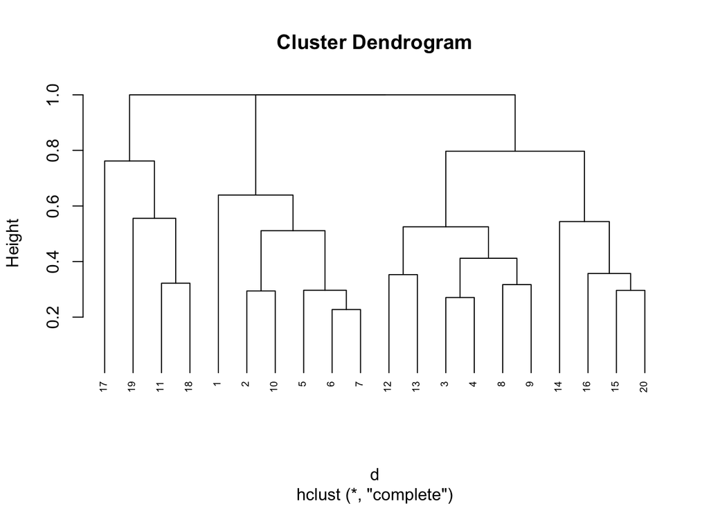

```r
# Hierarchical clustering using Complete Linkage
hc1 <- hclust(d, method = "complete" )

# Dendrogram plot of hc1
plot(hc1, cex = 0.6, hang = -1)
```

#### Hierarchical cluster 2

```r
# Compute agglomerative clustering with agnes
hc2 <- agnes(dune, method = "complete")

# Agglomerative coefficient
hc2$ac
```

```
## [1] 0.5398129
```

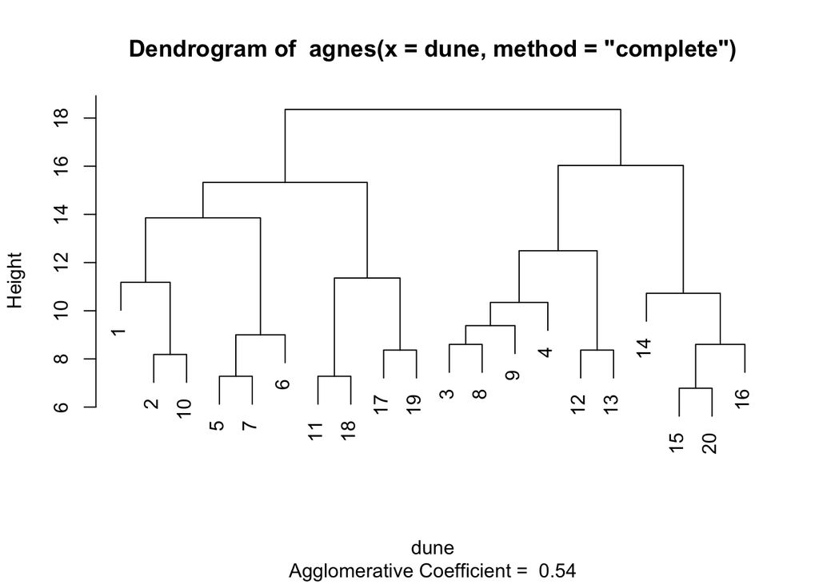

```r
# Dendrogram plot of hc2
plot(hc2, which.plot = 2)
```

```r
# methods to assess
m <- c( "average", "single", "complete", "ward")
names(m) <- c( "average", "single", "complete", "ward")

# function to compute coefficient
ac <- function(x) {
  agnes(dune, method = x)$ac
}

# get agglomerative coefficient for each linkage method
purrr::map_dbl(m, ac)
```

```
##   average    single  complete      ward
## 0.4067153 0.2007896 0.5398129 0.6939994
```

#### Hierarchical cluster 3

```r
# Compute ward linkage clustering with agnes
hc3 <- agnes(dune, method = "ward")

# Agglomerative coefficient
hc3$ac
```

```
## [1] 0.6939994
```

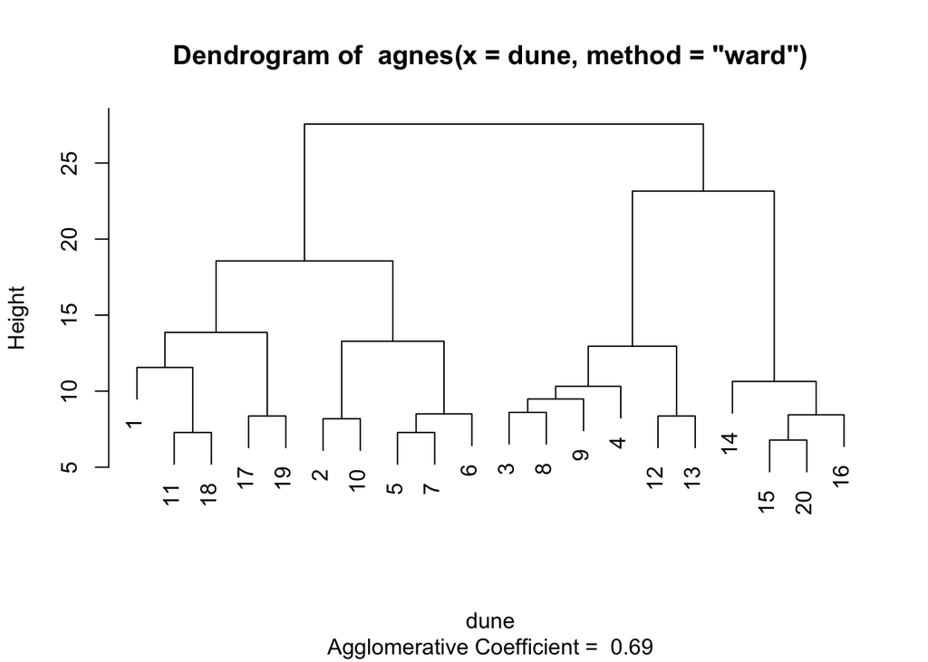

```r
# Dendrogram plot of hc3
plot(hc3, which.plot = 2)
```

### 1.2.5 Divisive hierarchical clustering on `dune`

```r
# DIvisive ANAlysis Clustering

# compute divisive hierarchical clustering
hc4 <- diana(dune)

# Divise coefficient; amount of clustering structure found
hc4$dc
```

```
## [1] 0.5287677
```

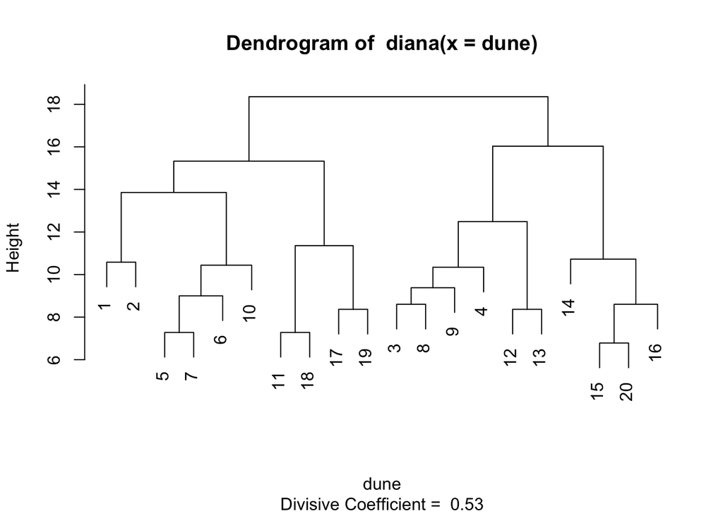

```r
plot(hc4, which.plot = 2)
```

### 1.2.6 Determining optimal clusters

- read [HOLMR 21.4](https://bradleyboehmke.github.io/HOML/hierarchical.html#determining-optimal-clusters)

```r
librarian::shelf(factoextra)
```

[output not shown]

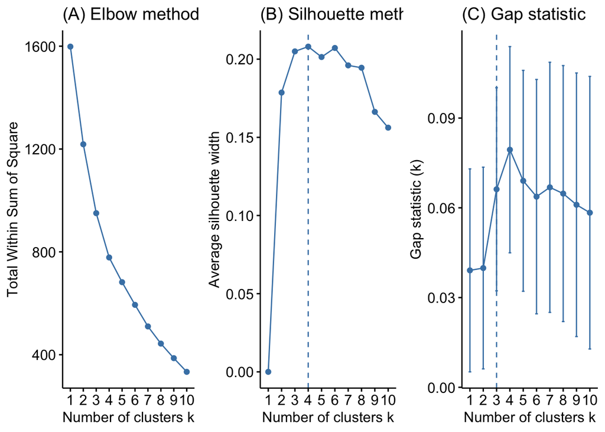

```r
# Plot cluster results
p1 <- fviz_nbclust(dune, FUN = hcut, method = "wss",  k.max = 10) +
  ggtitle("(A) Elbow method")

p2 <- fviz_nbclust(dune, FUN = hcut, method = "silhouette", k.max = 10) +
  ggtitle("(B) Silhouette method")

p3 <- fviz_nbclust(dune, FUN = hcut, method = "gap_stat", k.max = 10) +
  ggtitle("(C) Gap statistic")

# Display plots side by side
gridExtra::grid.arrange(p1, p2, p3, nrow = 1)
```

### 1.2.7 Working with Dendrograms

- See text to accompany code: [HOMLR 21.5 Working with dendrograms](https://bradleyboehmke.github.io/HOML/hierarchical.html#working-with-dendrograms).

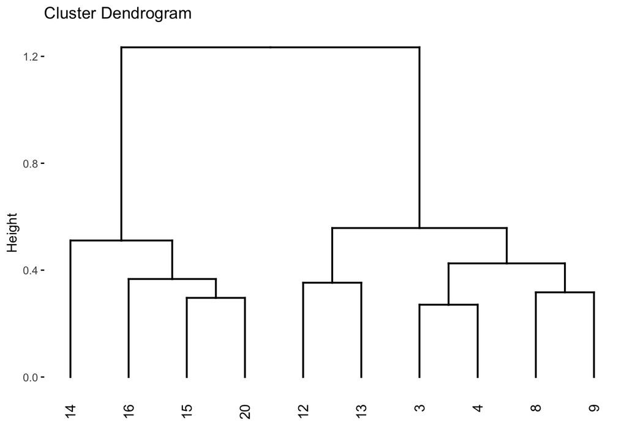

```r
# Construct dendorgram for the Ames housing example
hc5 <- hclust(d, method = "ward.D2" )
dend_plot <- fviz_dend(hc5)
dend_data <- attr(dend_plot, "dendrogram")
dend_cuts <- cut(dend_data, h = 8)
fviz_dend(dend_cuts$lower[[2]])
```

```r
# Ward's method
hc5 <- hclust(d, method = "ward.D2" )

# Cut tree into 4 groups
k = 4
sub_grp <- cutree(hc5, k = k)

# Number of members in each cluster
table(sub_grp)
```

```
## sub_grp
## 1 2 3 4
## 8 6 4 2
```

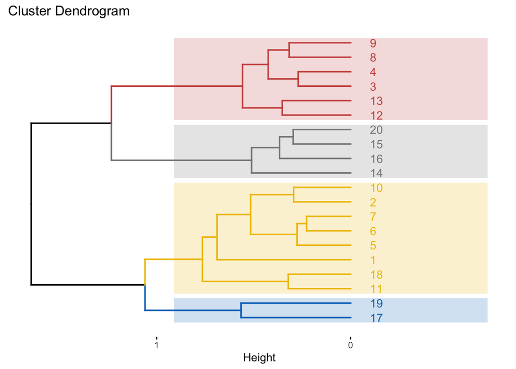

```r
# Plot full dendogram
fviz_dend(
  hc5,
  k = k,
  horiz = TRUE,
  rect = TRUE,
  rect_fill = TRUE,
  rect_border = "jco",
  k_colors = "jco")
```